[figure not shown]

# Artificial Intelligence and Machine Learning

# Cardio Good Fitness Project

# Ravi Potlachervu

[figure not shown]

# Objective

Cardio Good Fitness retail store team provided a dataset to identify differences between the customers of each product and explore the relationships between the different of the customers.

- Perform customer profiles the products sold by Cario Good Fitness.
- Perform univariate and multivatiate analyses.
- Generate a set of insights and recommendations that will help the company in targeting new customers.

# Dataset:

- **Product** - The model no. of the treadmill.
- **Age** - Age of the customer in no of years.
- **Gender** - Gender of the customer.
- **Education** - Education of the customer in no. of years.
- **Marital Status** - Marital status of the customer.
- **Usage** - Avg. # times the customer wants to use the treadmill every week.
- **Fitness** - Self rated fitness score of the customer (5 - very fit, 1 - very unfit).
- **Income** - Income of the customer.
- **Miles**- Miles that a customer expects to run.

### Data Sanity Checks

**Importing required libraries**

```python
# Import libraries used for reading and manipluting the dataset
import numpy as np  # library used to compute advanced mathematical operations
import pandas as pd # library used to read data and perform manipulation

# Import data visualization libraries
import matplotlib.pyplot as plt
import seaborn as sns

# Command to tell Python to actually display the graphs
%matplotlib inline

pd.set_option('display.float_format', lambda x: '%.2f' % x) # To supress numerical display in scientific notations
```

**Import the dataset**

```python
#Read dataset using panda function read_csv
data = pd.read_csv("CardioGoodFitness.csv")
```

**Understand the Dataset**

Let's start by performing basic steps to understand the data such as:

- Review first and last few rows of the dataset.
- Total no of rows and columns information.
- Identify data types of the columns
- checking the statistical summary

**Review first and last few rows of the dataset**

```python
#Display first few rows of the dataset
data.head()
```

|  | Product | Age | Gender | Education | MaritalStatus | Usage | Fitness | Income | Miles |
| --- | --- | --- | --- | --- | --- | --- | --- | --- | --- |
| 0 | TM195 | 18 | Male | 14 | Single | 3 | 4 | 29562 | 112 |
| 1 | TM195 | 19 | Male | 15 | Single | 2 | 3 | 31836 | 75 |
| 2 | TM195 | 19 | Female | 14 | Partnered | 4 | 3 | 30699 | 66 |
| 3 | TM195 | 19 | Male | 12 | Single | 3 | 3 | 32973 | 85 |
| 4 | TM195 | 20 | Male | 13 | Partnered | 4 | 2 | 35247 | 47 |

The dataset loaded without any issues

- *Dataset is in combination both numerical and String values*

```python
#Display last few rows of the dataset
data.tail()
```

|  | Product | Age | Gender | Education | MaritalStatus | Usage | Fitness | Income | Miles |
| --- | --- | --- | --- | --- | --- | --- | --- | --- | --- |
| 175 | TM798 | 40 | Male | 21 | Single | 6 | 5 | 83416 | 200 |
| 176 | TM798 | 42 | Male | 18 | Single | 5 | 4 | 89641 | 200 |
| 177 | TM798 | 45 | Male | 16 | Single | 5 | 5 | 90886 | 160 |
| 178 | TM798 | 47 | Male | 18 | Partnered | 4 | 5 | 104581 | 120 |
| 179 | TM798 | 48 | Male | 18 | Partnered | 4 | 5 | 95508 | 180 |

- *No Data anamolies found between first and last few rows*

**Total no of rows and columns information.**

```python
#checking shape of the data
data.shape
```

```
(180, 9)
```

- *The Dataset has 180 rows and 9 columns*

**Get the datatype information of the columns**

```python
#check data types of columns
data.info()
```

```
<class 'pandas.core.frame.DataFrame'>
RangeIndex: 180 entries, 0 to 179
Data columns (total 9 columns):
 #   Column         Non-Null Count  Dtype
---  ------         --------------  -----
 0   Product        180 non-null    object
 1   Age            180 non-null    int64
 2   Gender         180 non-null    object
 3   Education      180 non-null    int64
 4   MaritalStatus  180 non-null    object
 5   Usage          180 non-null    int64
 6   Fitness        180 non-null    int64
 7   Income         180 non-null    int64
 8   Miles          180 non-null    int64
dtypes: int64(6), object(3)
memory usage: 12.8+ KB
```

- *There are 6 numerical columns and 3 object type columns and these can be considered a categorical variables .*
- *Basic observation show there are no missing values.*
- *All the columns have 180 non-null values*

**Checking for missing values in the data**

```python
data.isnull().sum()
```

```
Product          0
Age              0
Gender           0
Education        0
MaritalStatus    0
Usage            0
Fitness          0
Income           0
Miles            0
dtype: int64
```

- This confirms there are no missing values in the dataset.

**Checking for duplicate values in the dataset**

```python
data.duplicated().sum()
```

```
0
```

- There are no duplicate values in the dataset.

**Getting the statistical summary for the dataset**

```python
data.describe(include='all').T
```

|  | count | unique | top | freq | mean | std | min | 25% | 50% | 75% | max |
| --- | --- | --- | --- | --- | --- | --- | --- | --- | --- | --- | --- |
| Product | 180 | 3 | TM195 | 80 | NaN | NaN | NaN | NaN | NaN | NaN | NaN |
| Age | 180.00 | NaN | NaN | NaN | 28.79 | 6.94 | 18.00 | 24.00 | 26.00 | 33.00 | 50.00 |
| Gender | 180 | 2 | Male | 104 | NaN | NaN | NaN | NaN | NaN | NaN | NaN |
| Education | 180.00 | NaN | NaN | NaN | 15.57 | 1.62 | 12.00 | 14.00 | 16.00 | 16.00 | 21.00 |
| MaritalStatus | 180 | 2 | Partnered | 107 | NaN | NaN | NaN | NaN | NaN | NaN | NaN |
| Usage | 180.00 | NaN | NaN | NaN | 3.46 | 1.08 | 2.00 | 3.00 | 3.00 | 4.00 | 7.00 |
| Fitness | 180.00 | NaN | NaN | NaN | 3.31 | 0.96 | 1.00 | 3.00 | 3.00 | 4.00 | 5.00 |
| Income | 180.00 | NaN | NaN | NaN | 53719.58 | 16506.68 | 29562.00 | 44058.75 | 50596.50 | 58668.00 | 104581.00 |
| Miles | 180.00 | NaN | NaN | NaN | 103.19 | 51.86 | 21.00 | 66.00 | 94.00 | 114.75 | 360.00 |

**Review the count and percentage of categorical levels in each column**

```python
# Printing the count of unique categorical levels in each column
for column in cat_var:
    print(data[column].value_counts())
    print("-" * 50)
```

```
TM195    80
TM498    60
TM798    40
Name: Product, dtype: int64
--------------------------------------------------
Male      104
Female     76
Name: Gender, dtype: int64
--------------------------------------------------
Partnered    107
Single        73
Name: MaritalStatus, dtype: int64
--------------------------------------------------
```

```python
for column in cat_var:
    print(data[column].value_counts(normalize=True))
    print("-" * 50)
```

```
TM195   0.44
TM498   0.33
TM798   0.22
Name: Product, dtype: float64
--------------------------------------------------
Male     0.58
Female   0.42
Name: Gender, dtype: float64
--------------------------------------------------
Partnered   0.59
Single      0.41
Name: MaritalStatus, dtype: float64
--------------------------------------------------
```

**Observations**

## Univariate Analysis

Lets check data distribution on numerical columns

```python
#create a variable to get list of numerical columns
num_col=data.select_dtypes(include=np.number).columns.tolist()
```

```python
#Create a function to combined histogram and boxplot  graphing
def hist_box(col):
    fig, axs = plt.subplots(1, 2,figsize=(10, 3))
    sns.histplot(data=data, x=col, kde=True, ax=axs[0]);
    sns.boxplot(data=data, x=col, ax=axs[1]);
```

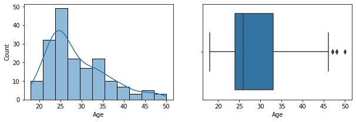

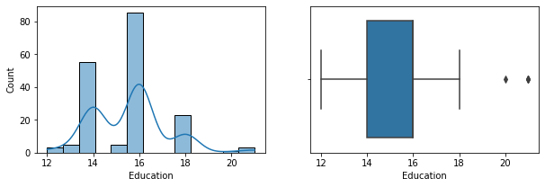

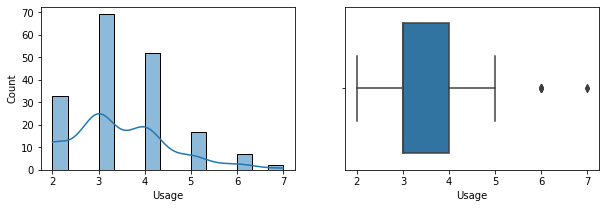

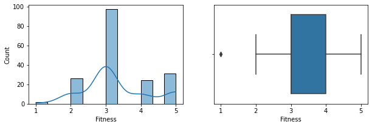

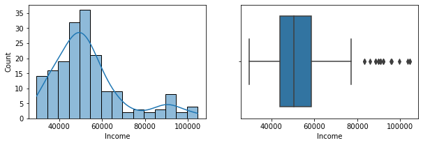

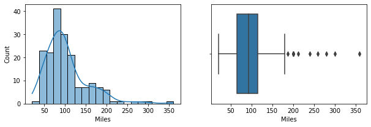

```python
#Create to both histgram and boxplot graph for all numerical columns.
for i in num_col:
    hist_box(data[i]) # Call hist_box function for each column.
```

*Observations*

**Age**

- Age distribution is more right skewed.
- Very few outliers toward right.
- Majority of products are bought age group between 20 to 40 and very less number of before 20 and after 40.

**Education**

- Majority of customers have 14 to 18 years of eduction.
- Very few outliers towards right.

**Usage**

- Usage distribution is more right skewed.
- Most of users use products about 2 - 4 times/week.
- There are very few outliers towards right.

**Fitness**

- Fitness data shows more left skewed
- Very few number of customers have low fitness score.
- Very few outlier towards left.

**Income**

- Income data is more skewed towards right.
- There are wide range outliers on this column. However values seems to be valid and we are going treat these values
- Majority of customers income range from 30K to 70K.
- There are not many customer who earn more than 70K

**Miles**

### Outlier Detection and Treatment

- Based on the above observation will not remove any outliers.

**Observations on Categorical Attributes**

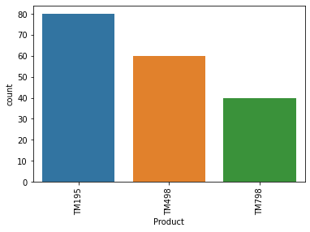

```python
sns.countplot(data=data,x='Product')
plt.xticks(rotation=90)
plt.show()
```

- Most customer use product'TM195' and followed by 'TM498'. This indicates TM195 is best selling product

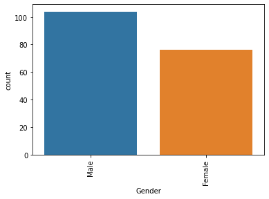

```python
sns.countplot(data=data,x='Gender')
plt.xticks(rotation=90)
plt.show()
```

- Majority of products are bought by Male'. This indicates there more male buyers then female

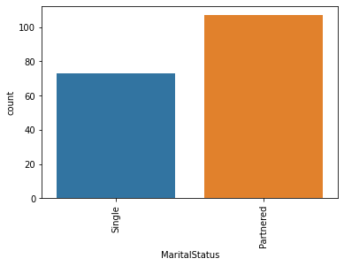

```python
sns.countplot(data=data,x='MaritalStatus')
plt.xticks(rotation=90)
plt.show()
```

- Majority of the product are bought by 'Partnered' Marital Status.Indicates partnered buying more products then singles.

## Bivariate Analysis.

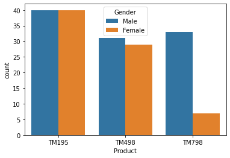

```python
#Products analsys with Gender
sns.countplot(data=data, x='Product', hue='Gender');
```

- Product TM798 is more bought by Male custems and TM195 is equally bought by male and female customers.

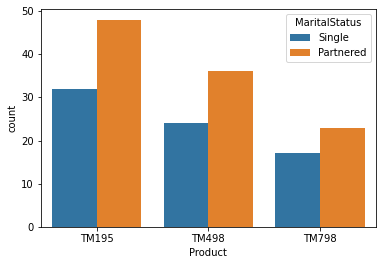

```python
#Product analysis with Marital Status
sns.countplot(data=data, x='Product', hue='MaritalStatus');
```

- TM195 product is more bought by Couples.

```python
#Product analysis with Marital Status
sns.countplot(data=data, x='Product', hue='MaritalStatus');
```

[output not shown]

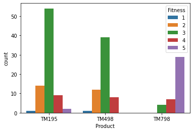

```python
#let product analysis with fitness levels
sns.countplot(data=data, x='Product', hue='Fitness');
```

- Customers with fitness level below 3 tend to use TM195 and TM498.
- Customers who used TM798 have hight fitness level.

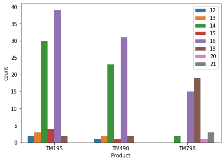

```python
#lets do product analysis with Educations years.
plt.figure(figsize=(7,5))
sns.countplot(data=data, x='Product', hue='Education');
plt.legend(bbox_to_anchor=[1,1]);
```

- Most of the products are bought by customers with 16 yrs of education.
- TM198 is popular among customers with 18 yrs of eduction
- Customers with 20 yrs eduction only bought TM798 model.

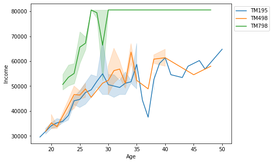

```python
#lets do product analysis with Age.
plt.figure(figsize=(7,5))
sns.lineplot(data=data, x='Age',y='Income', hue='Product');
plt.legend(bbox_to_anchor=[1,1]);
```

- Customer with higher income above 70K prefer to buy TM798

**Lets do more Product analysis on Age and Income**

- Above lineplot show there is more significance on Age and Income for product sales. Lets create Age groups and Income ranges using pd.cut() fuinction.

```python
data['Age'].min(),data['Age'].max()
```

```
(18, 50)
```

**Creating bins for Age bins**

- 15 - 25 Age - Label **`Young`**.
- 25 - 35 Age - Label **`Young Adults`**.
- 35 - 45 Age - Label **`Middle-Aged Adults`**.
- 45 - 55 Age - Lable **`Old Adults`**.

We will use pd.cut funtion to create bins on Age column

```python
# using pd.cut fuction to create bins

data['AgeType'] = pd.cut(data['Age'],bins=[15,25,35,45,55],labels=['Young','Young Adults','Middle-Aged Adults', 'Old Adults'], right = False)
```

```python
data.head()
```

|  | Product | Age | Gender | Education | MaritalStatus | Usage | Fitness | Income | Miles | AgeType |
| --- | --- | --- | --- | --- | --- | --- | --- | --- | --- | --- |
| 0 | TM195 | 18 | Male | 14 | Single | 3 | 4 | 29562 | 112 | Young |
| 1 | TM195 | 19 | Male | 15 | Single | 2 | 3 | 31836 | 75 | Young |
| 2 | TM195 | 19 | Female | 14 | Partnered | 4 | 3 | 30699 | 66 | Young |
| 3 | TM195 | 19 | Male | 12 | Single | 3 | 3 | 32973 | 85 | Young |
| 4 | TM195 | 20 | Male | 13 | Partnered | 4 | 2 | 35247 | 47 | Young |

```python
data['Income'].min(),data['Income'].max()
```

```
(29562, 104581)
```

**Creating bins for Income bins**

- 29000 - 59000 Income - Label **`Low Income`**.
- 59000 - 79000 Income - Label **`Middle Income`**.
- 79000 - 109000 Income - Label **`High Income`**.

We will use pd.cut funtion to create bins on Income column

```python
# using pd.cut fuction to create bins

data['IncomeLevel'] = pd.cut(data['Income'],bins=[29000,59000,79000,109000],labels=['Low','Middle','High'], right = False)
```

```python
data.head()
```

|  | Product | Age | Gender | Education | MaritalStatus | Usage | Fitness | Income | Miles | AgeType | IncomeLevel |
| --- | --- | --- | --- | --- | --- | --- | --- | --- | --- | --- | --- |
| 0 | TM195 | 18 | Male | 14 | Single | 3 | 4 | 29562 | 112 | Young | Low |
| 1 | TM195 | 19 | Male | 15 | Single | 2 | 3 | 31836 | 75 | Young | Low |
| 2 | TM195 | 19 | Female | 14 | Partnered | 4 | 3 | 30699 | 66 | Young | Low |
| 3 | TM195 | 19 | Male | 12 | Single | 3 | 3 | 32973 | 85 | Young | Low |
| 4 | TM195 | 20 | Male | 13 | Partnered | 4 | 2 | 35247 | 47 | Young | Low |

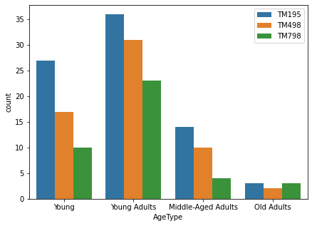

```python
#lets do product analysis with AgeGroup.
plt.figure(figsize=(7,5))
sns.countplot(data=data, x='AgeType', hue='Product');
plt.legend(bbox_to_anchor=[1,1]);
```

TM195 is more popular among 'Young', 'Young Adults' and Middle-Aged Adults groups.

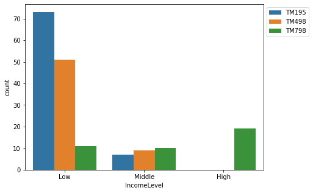

```python
#lets do product analysis with Incomelevel.
plt.figure(figsize=(7,5))
sns.countplot(data=data, x='IncomeLevel', hue='Product');
plt.legend(bbox_to_anchor=[1,1]);
```

- TM195 model is more popular for customers will low income levels(29K-59K).
- TM798 is more popular among High income customers (79K - 104K)

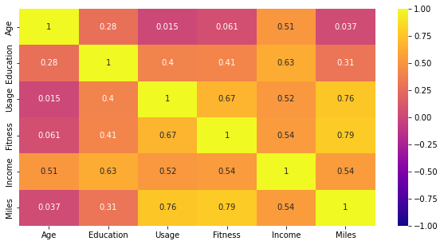

```python
#Create heatmap for all numerical column to review correlation
plt.figure(figsize=(10,5))
sns.heatmap(data.corr(),annot=True,cmap='plasma',vmin=-1,vmax=1)
plt.show()
```

**Observations:**

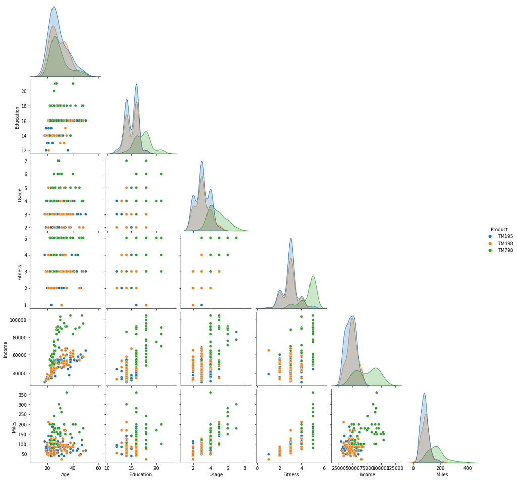

```python
# Create pairplot for all numerical columns with hue as product, this gives overall picture of the data.
sns.pairplot(data=data, hue='Product', corner=True);
```

*Observation*

- Most customer use product'TM195' and followed by 'TM498'. This indicates TM195 is best selling product
- Males tend to buy more product than Females.
- TM195 product is more bought by Couples.
- Customers with fitness level below 3 tend to use TM195 and TM498.
- Customers who used TM798 have hight fitness level.
- Most of the products are bought by customers with 16 yrs of education.
- TM198 is popular among customers with 18 yrs of eduction
- Customers with 20 yrs eduction only bought TM798 model.
- Customer with higher income above 70K prefer to buy TM798.
- TM195 is more popular among 'Young'(15-25), 'Young Adults(25-35)' and Middle-Aged Adults(35-45) groups.
- TM195 model is more popular for customers will low income levels(29K-59K).
- TM798 is more popular among High income customers (79K - 104K)

```python
data.head()
```

|  | Product | Age | Gender | Education | MaritalStatus | Usage | Fitness | Income | Miles | AgeType | IncomeLevel |
| --- | --- | --- | --- | --- | --- | --- | --- | --- | --- | --- | --- |
| 0 | TM195 | 18 | Male | 14 | Single | 3 | 4 | 29562 | 112 | Young | Low |
| 1 | TM195 | 19 | Male | 15 | Single | 2 | 3 | 31836 | 75 | Young | Low |
| 2 | TM195 | 19 | Female | 14 | Partnered | 4 | 3 | 30699 | 66 | Young | Low |
| 3 | TM195 | 19 | Male | 12 | Single | 3 | 3 | 32973 | 85 | Young | Low |
| 4 | TM195 | 20 | Male | 13 | Partnered | 4 | 2 | 35247 | 47 | Young | Low |

## Multivariate Analysis.

- Age, Income, Gender, MaritalStatus play major role on selling products.

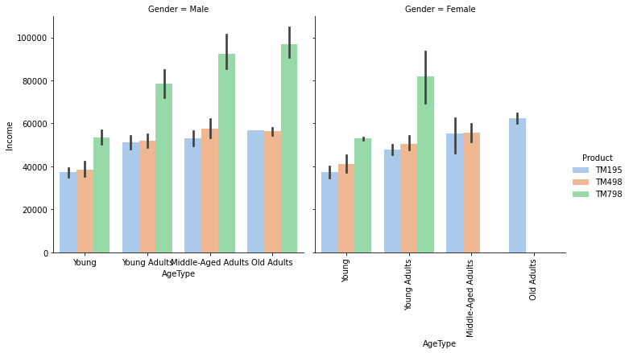

```python
sns.catplot(data=data, x="AgeType", y="Income", hue="Product", col="Gender", kind='bar', palette='pastel');
plt.xticks(rotation=90)
plt.show()
```

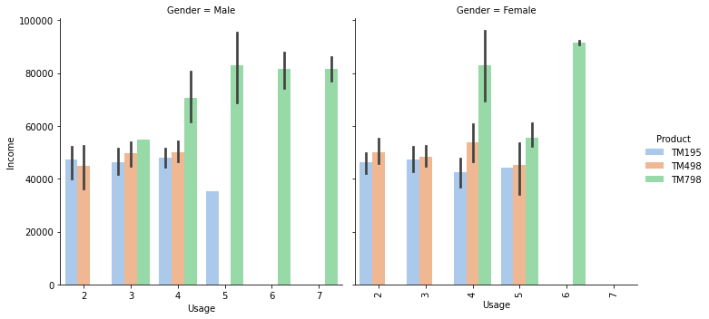

```python
sns.catplot(data=data, x="Usage", y="Income", hue="Product", col="Gender", kind='bar', palette='pastel');
plt.xticks(rotation=90)
plt.show()
```

- Male and female customers with income above 60K and prefer to buy TM798 and use above 4 times/weeks

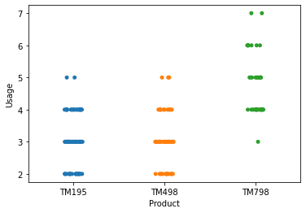

```python
sns.stripplot(data=data, x='Product', y='Usage');
```

- Customers who bought TM798 they tend to use more than customers who bought TM195 and TM198

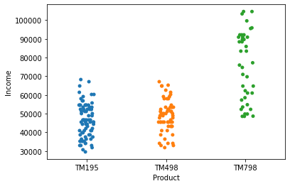

```python
sns.stripplot(data=data, x='Product', y='Income');
```

- Customers with income less than 70K more likely to buy TM195 and TM498 products.

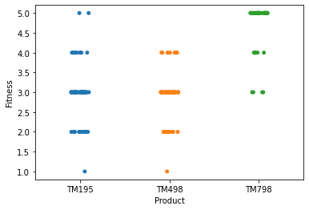

```python
sns.stripplot(data=data, x='Product', y='Fitness');
```

- Customers who bought TM798 models have minimum fitness level of 3.

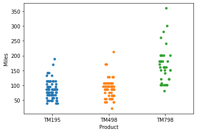

```python
sns.stripplot(data=data, x='Product', y='Miles');
```

## Conclusion

- CardioFitness sells three different Treadmill products (TM195,TM498,TM798).
- Most selling product is TM195 and followed by TM498 and least selling is TM798. I guess TM798 is highend and expensive product.
- There are more Male buyers than female. Recommend company focus more marketing towards male customers.
- Couples bought more products than Singles.
- TM195 product is more bought by Couples.
- Customers with fitness level below 3 more likely to by TM195 and TM498.
- Customers who used TM798 have hight fitness levels.
- Most of the products are bought by customers with 16 yrs of education.
- TM198 is popular among customers with 18 yrs of education
- Customers with 20 yrs eduction only bought TM798 model.
- Customer with higher income above 70K prefer to buy TM798. Most of the customers have income below 70K and they they prefer to buy TM195 and TM498 models
- TM195 is more popular among 'Young'(15-25), 'Young Adults(25-35)' and Middle-Aged Adults(35-45) groups.
- TM195 model is more popular for customers will low income levels(29K-59K).
- TM798 is more popular among High income customers (79K - 104K).
- I include outlier on Bivariate Analsys, as I dont see any importance to exclude outliers.

# Customer Profiling

- Based on above analysis, I recommend Cardio Fitness should do more marketing on TM798 and target customers with higher income and higher education years to improve sales.
- TM195 and TM498 is more popular among young and young Adult customers, targeting younger crowd may increase sales of these models.
- Target marketing customers with education years above 16yrs. They more like to buy fitnes products.